# Week 6 - Weekend Homework - Mahri

# Hypothesis tests & probability - homework

## MVP

### Hypothesis testing - practical

You work for an animal conservation organisation and are looking to do some investigating into some of the animals to provide evidence for some projects you are looking to run.

In this homework we’ll use the `msleep` data set provided in the `ggplot` package. It concerns the sleeping patterns of various types of mammal.

```r
library(tidyverse)
library(ggplot2)
library(janitor)
library(infer)
```

**Question 1.**  
Explore the dataset and familiarise yourself with it.

```r
data(msleep)
glimpse(msleep)
```

```
Rows: 83
Columns: 11
$ name         <chr> "Cheetah", "Owl monkey", "Mountain beaver", "Greater short-tailed shrew", "Cow", "Three-toed sloth~
$ genus        <chr> "Acinonyx", "Aotus", "Aplodontia", "Blarina", "Bos", "Bradypus", "Callorhinus", "Calomys", "Canis"~
$ vore         <chr> "carni", "omni", "herbi", "omni", "herbi", "herbi", "carni", NA, "carni", "herbi", "herbi", "herbi~
$ order        <chr> "Carnivora", "Primates", "Rodentia", "Soricomorpha", "Artiodactyla", "Pilosa", "Carnivora", "Roden~
$ conservation <chr> "lc", NA, "nt", "lc", "domesticated", NA, "vu", NA, "domesticated", "lc", "lc", "domesticated", "l~
$ sleep_total  <dbl> 12.1, 17.0, 14.4, 14.9, 4.0, 14.4, 8.7, 7.0, 10.1, 3.0, 5.3, 9.4, 10.0, 12.5, 10.3, 8.3, 9.1, 17.4~
$ sleep_rem    <dbl> NA, 1.8, 2.4, 2.3, 0.7, 2.2, 1.4, NA, 2.9, NA, 0.6, 0.8, 0.7, 1.5, 2.2, 2.0, 1.4, 3.1, 0.5, 4.9, N~
$ sleep_cycle  <dbl> NA, NA, NA, 0.1333333, 0.6666667, 0.7666667, 0.3833333, NA, 0.3333333, NA, NA, 0.2166667, NA, 0.11~
$ awake        <dbl> 11.90, 7.00, 9.60, 9.10, 20.00, 9.60, 15.30, 17.00, 13.90, 21.00, 18.70, 14.60, 14.00, 11.50, 13.7~
$ brainwt      <dbl> NA, 0.01550, NA, 0.00029, 0.42300, NA, NA, NA, 0.07000, 0.09820, 0.11500, 0.00550, NA, 0.00640, 0.~
$ bodywt       <dbl> 50.000, 0.480, 1.350, 0.019, 600.000, 3.850, 20.490, 0.045, 14.000, 14.800, 33.500, 0.728, 4.750, ~
```

```r
head(msleep, 10)
```

| name | genus | vore | order | conservation | sleep_total | sleep_rem | sleep_cycle | awake | brainwt | bodywt |
| --- | --- | --- | --- | --- | --- | --- | --- | --- | --- | --- |
| Cheetah | Acinonyx | carni | Carnivora | lc | 12.1 | NA | NA | 11.9 | NA | 50.000 |
| Owl monkey | Aotus | omni | Primates | NA | 17.0 | 1.8 | NA | 7.0 | 0.01550 | 0.480 |
| Mountain beaver | Aplodontia | herbi | Rodentia | nt | 14.4 | 2.4 | NA | 9.6 | NA | 1.350 |
| Greater short-tailed shrew | Blarina | omni | Soricomorpha | lc | 14.9 | 2.3 | 0.1333333 | 9.1 | 0.00029 | 0.019 |
| Cow | Bos | herbi | Artiodactyla | domesticated | 4.0 | 0.7 | 0.6666667 | 20.0 | 0.42300 | 600.000 |
| Three-toed sloth | Bradypus | herbi | Pilosa | NA | 14.4 | 2.2 | 0.7666667 | 9.6 | NA | 3.850 |
| Northern fur seal | Callorhinus | carni | Carnivora | vu | 8.7 | 1.4 | 0.3833333 | 15.3 | NA | 20.490 |
| Vesper mouse | Calomys | NA | Rodentia | NA | 7.0 | NA | NA | 17.0 | NA | 0.045 |
| Dog | Canis | carni | Carnivora | domesticated | 10.1 | 2.9 | 0.3333333 | 13.9 | 0.07000 | 14.000 |
| Roe deer | Capreolus | herbi | Artiodactyla | lc | 3.0 | NA | NA | 21.0 | 0.09820 | 14.800 |

```r
NA
```

**Question 2.**  
Jabberwockies sleep for around 7 hours a night, on average. Perform an appropriate statistical test to determine whether the mean `sleep_total` in the sampled population of animal types differs from the typical value for jabberwockies.

```r
obs_stat_sleep_total <- msleep %>%
  summarise(mean_sleep = round(mean(sleep_total), 2))
obs_stat_sleep_total
```

| mean_sleep |
| --- |
| 10.43 |

```r
# The mean sleep total for all animals = 10.43 hours

# Does the mean DIFFER from the population sample mean - two tailed as it's not
# asking if it's more or less.

# H0: There is no difference between the mean hours of sleep for jabberwockies
# and the population.
# H1: The mean hours of sleep for the population differs from that of the
# jabberwockies.

# create a null distribution
# 7 is the average hours of sleep for the jabberwockie (mu = hypothesis mean
#  and we're hypothesizing that the population mean is the same)
null_distribution_total_sleep <- msleep %>%
  specify(response = sleep_total) %>%
  hypothesise(null = "point", mu = 7) %>%
  generate(reps = 50000, type = "bootstrap") %>%
  calculate(stat = "mean")
null_distribution_total_sleep
```

```
Response: sleep_total (numeric)
Null Hypothesis: point
```

| replicate | stat |
| --- | --- |
| 1 | 7.532530 |
| 2 | 7.302410 |
| 3 | 6.950602 |
| 4 | 6.446988 |
| 5 | 6.797590 |
| 6 | 6.439759 |
| 7 | 6.874699 |
| 8 | 7.103614 |
| 9 | 7.761446 |
| 10 | 7.007229 |

[output cut: 990 more lines]

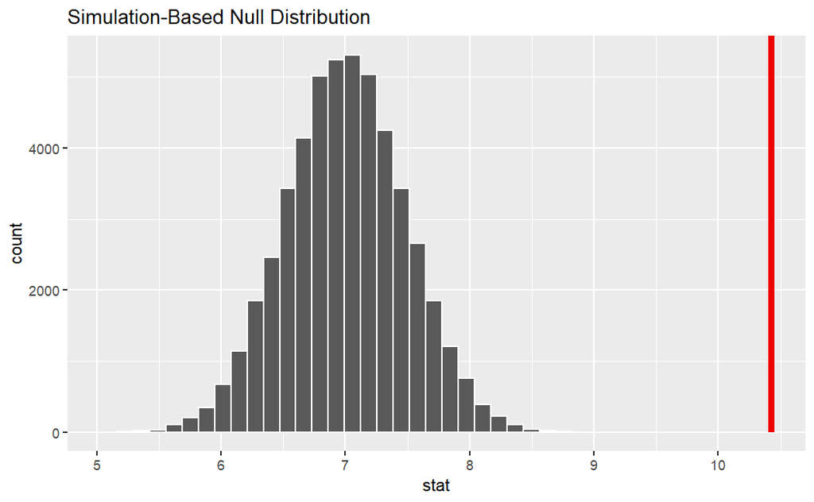

```r
# Visualise. The red line will be our observed stat i.e. the mean for the
# population.
# The bars will be the means of means.
null_distribution_total_sleep %>%
  visualise(bins = 30) +
  shade_p_value(obs_stat = obs_stat_sleep_total, direction = "both")
```

```r
# p value
p_value_sleep_total <- null_distribution_total_sleep %>%
  get_p_value(obs_stat = obs_stat_sleep_total$mean_sleep, direction = "both")
p_value_sleep_total
```

| p_value |
| --- |
| 0 |

```r
# p = 0.
# As p < 0.05, we can reject our null hypothesis in favour of the alternative
# hypotheseis - the mean hours of sleep for the population differs from that of
# the jabberwockies.
```

**Question 3.**  
Perform an appropriate statistical test to determine whether omnivores sleep for significantly longer than herbivores, on average.

```r
# This is one tailed (right-tailed) ("do they sleep MORE")

# H0: Omnivores do not sleep for a significantly longer time than herbivores.
# H1: Omnivores sleep for a significantly longer time than herbivores.


omnis_and_herbis <- msleep %>%
  filter(vore %in% c("omni", "herbi"))

omnis_and_herbis %>%
  group_by(vore) %>%
  summarise(count = n())
```

| vore | count |
| --- | --- |
| herbi | 32 |
| omni | 20 |

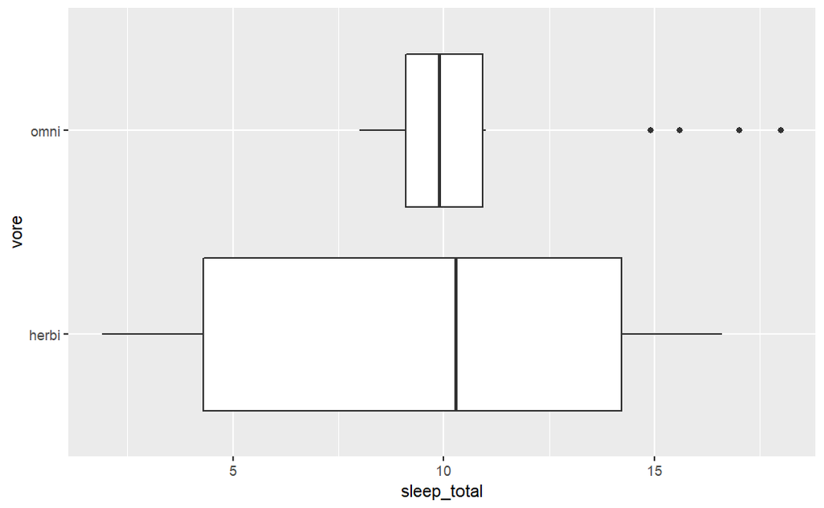

```r
# There are 20 omnivores and 32 Herbivores


omnis_and_herbis %>%
  ggplot()+
  aes(x = sleep_total, y = vore) +
  geom_boxplot()
```

```r
# Just having a look. The average scores are quite close but very different
# ranges - omnivores mostly sleep for similar amounts of time with some
# outliers, herbivores much more spread
```

Theoretical distribution: (observed below)

```r
null_distribution_omni_herbi <- omnis_and_herbis %>%
  specify(sleep_total ~ vore) %>%
  hypothesise(null = "independence") %>%
  generate(reps = 5000, type = "permute") %>%
  calculate(stat = "diff in means", order = c("omni", "herbi"))
null_distribution_omni_herbi
```

```
Response: sleep_total (numeric)
Explanatory: vore (factor)
Null Hypothesis: independence
```

| replicate | stat |
| --- | --- |
| 1 | 0.578750 |
| 2 | -0.014375 |
| 3 | -2.346250 |
| 4 | -2.703750 |
| 5 | -1.143750 |
| 6 | -0.802500 |
| 7 | -0.656250 |
| 8 | 0.261875 |
| 9 | -0.152500 |
| 10 | -0.298750 |

[output cut: 990 more lines]

Observed/ empirical distribution (theoretical above) and p-value:

```r
observed_stat_omni_herbi <- omnis_and_herbis %>%
  specify(sleep_total ~ vore) %>%
  calculate(stat = "diff in means", order = c("omni", "herbi"))
observed_stat_omni_herbi
```

```
Response: sleep_total (numeric)
Explanatory: vore (factor)
```

| stat |
| --- |
| 1.415625 |